# 上級マクロ経済学II

第1回 イントロダクション

Author

荻巣嘉高

# 1 イントロダクション

## 授業概要

- 近年において観測、収集される多量なデータ、分析を適切に解釈するためには一定水準の知的地盤が必要となる。
- マクロ経済学の発展的なトピックスを紹介することを通じて、データと理論を比較しながら経済を見る目を養う。

## 到達目標

- マクロ経済学の発展的トピックスを概観する。
- 基本的な経済モデルの含意を理解する。
- マクロデータの分析と分析結果の読み方を理解する。

## 成績評価

- 課題（10点）
  - 講義で用いられている図表や結果を再現するレポートを作成してもらいます。
- 期末テスト（90点）
  - 記述式が中心。
  - 講義内容を踏まえて以下のような方針で作成：
    - 基礎的なモデルの構築と含意を問う問題
    - 論理展開を問う問題
- 講義への貢献（$+\alpha/$max 10点）
  - 質疑（質問システム）

## 講義予定

1. イントロダクション
2. ソローモデルと収束
3. 公共セクターの役割
4. 2期間モデルと世代重複モデル
5. 人的資本
6. 人口動態と社会保障
7. 内生的成長
8. 技術偏向経済成長
9. 景気循環とその抽出
10. 失業
11. 期待とマクロ経済
12. 実物景気循環モデル
13. ニューケインジアンモデル
14. ミクロショックとマクロ変動
15. まとめ

## テキスト

- 教科書は指定しません。
- 配布資料をもとに講義を進めます。
  - HPの[講義ページ](https://yoshitaka-ogisu.github.io/homepage/course_page/advanced_macroeconomicsII.html)（My KONANにリンク貼っておきます）からDLしておいてください。
- 参考資料は次のページを参照してください。

## 参考書

1. 二神孝一・堀敬一（2017）『マクロ経済学 第2版』有斐閣
2. 二神孝一・堀敬一（2025）『マクロ経済学 第3版 基礎編』有斐閣
3. 齊藤誠・岩本康志・太田聰一・柴田章久（2016）『マクロ経済学 新版』有斐閣
4. 楡井誠（2023）『マクロ経済動学: 景気循環の起源の解明』有斐閣
5. 北尾早霧・砂川武貴・山田知明（2024）「定量的マクロ経済学と数値計算」日本評論社
6. 加藤涼「現代マクロ経済学講義―動学的一般均衡モデル入門」東洋経済新報社
7. 平口良司・稲葉大（2023）「マクロ経済学 第3版: 入門の「一歩前」から応用まで 」有斐閣
8. 福田慎一・照山 博司（2023）「マクロ経済学・入門 第6版」有斐閣
- 本講義で取り扱う議論と最も近いレベル帯に属するのは1、2、3。
- 一部の、新しいトピックスは学部上級から大学院向けのレベルのテキストである4、5、6などを元にしている
  - 単純化したモデル等を用いる予定。
- IS-LM分析やAD-AS分析等、伝統的なケインジアンのマクロ経済学の議論について学習に不安がある場合、7や8のテキストを用いて自習するとよい。

## 前提条件1

- 数学
  - 連立方程式、微分、確率は使います。
  - 積分は記号が出てくるかもしれません。
    - ただし、具体的な積分計算は問わないです。
- 統計学
  - 中級統計学の内容は知っているものとして進みます。
  - 中級統計学の単位を習得していなくても構いませんが、キャッチアップは各自でやってください。
  - 推測統計の基本的なお話がわかっていればOKです。
- これらに不安のある人は、講義ページの補足資料を読みながら講義を受けるのをお勧めします。

## 前提条件２

- マクロ経済学
  - 中級マクロ経済学、上級マクロ経済学Iの内容は知っているものとして進みます。
  - 重要な概念の簡単な解説は行いますが、ソローモデル、オイラー方程式を聞いたことがある方がフォローしやすいです。
- プログラム関連
  - プログラミング課題を行います。
    - プログラミング言語は何を使っても構いません。
    - Stataの使い方は後日動画を配布予定なので、プログラミングの知識がなくてもOKです。

## 前提条件3

たぶんきついです。

- 履修は計画的に。

## 評価基準（期末テスト）

- 記述式
  - 問いに答えているか。
  - 論理が破綻していないか。

## 評価基準 （課題）

- プログラミング課題です。
  - コードと出力結果をレポートにまとめる。
  - 指示がきちんと守られているか。
  - コードがちゃんと動くか。
  - 正しいレプリケーションになっているか。
- Stataの使い方動画を後日アップロードします。

## プログラミング言語の選択

- Stata
  - My KONANを通じて配布します。
- Python
- R
- Matlab
- gretl
- C++

以上の言語なら読めます。

# 2 小話

## 経済学の立ち位置

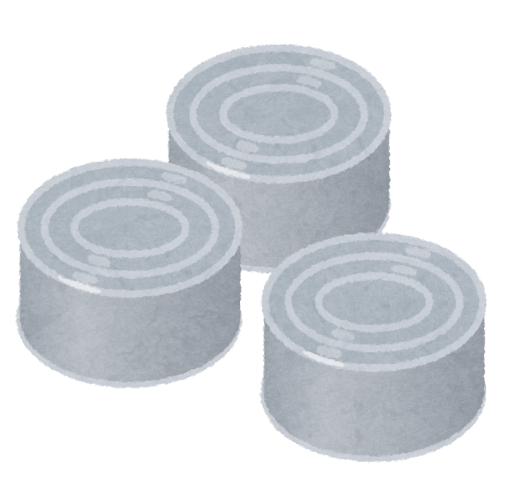

無人島に化学者、物理学者、経済学者の3人が漂流

> 食料缶が流れ着いている
- **化学者**：火をおこして、缶を炙ってみよう
- **物理学者**：高いところから落としてみよう
- **経済学者**：

「ここに缶切りがあると仮定しよう…」

## 経済理論は現実をとらえていない？

「したがって、学んでも意味がない」

現実とフィットするものを作って、現実を理解したい

> 工学系

現実の中から、一部を切り取って、その*メカニズム*を明らかにしたい

> 物理系

経済学は後者に近い考え方。

- 他の状況は一定と考えた時に
- ある重要なメカニズムの経路（パス）を明らかにする

## 経済モデルの役割

- なんの**歪み**もない、まっさら+シンプルな状態からスタート
  - **歪み**：市場を完全競争からかい離させる要因
- 現実とのギャップを捉える
- ギャップの要因が何かを探る

モデルは重要なベンチマークとしての役割を持つ。

# 3 ソローモデルの復習

## ソローモデルの概要

- 上級マクロ経済学Iでやっている（はず）

マクロ経済学を大まかにふたつに分けると、

- 経済成長理論
  - ソローモデル
  - AKモデル
  - ラムゼイモデル
- ビジネスサイクル（景気循環）理論
  - 45度分析、IS-LMモデル
  - RBC（実物景気循環、リアルビジネスサイクル）モデル
  - DSGEモデル（Dynamic Stochastic General Equilibrium model）

## モデル

基本の連立方程式
$$\begin{aligned}
Y_t &= F(K_t,L_t), \\
K_{t+1} - K_{t} &= s F(k_t) - \delta K_t
\end{aligned}$$

$Y_t$：GDP、$F(\cdot)$：生産関数、$K_t$：資本、$L_t$：労働

$s$：貯蓄率、$\delta$：資本減耗率

## 一人当たりの描写

$k_t \equiv K_t/ L_t$

$1+n_t = L_{t+1} / L_t$

$y_t = f(k_t) = Y_t/L_t = F(K_t, L_t)/L_t = F(K_t/L_t, 1) = F(k_t, 1)$

## 定常状態を描写

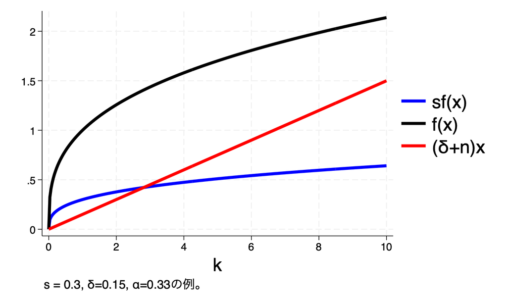

定常状態は
$$k_t = k_{t+1} = k^\ast$$
のとき。

そのときは、
$$s f(k^\ast) = (\delta + n) k^\ast$$

- 次回また一通り復習します。

## まとめ

- 単位を揃えたい人、頑張ってください。
- それなりの数学的な知識がある前提で進めていきます。。
- フォローが必要な人は、随時荻巣にコンタクトを取っていただいて構いません。